# Problem Statement

An E-Commerce company based in New York City that sells clothing online but they also have in-store style and clothing advice sessions. Customers come into the store, have sessions/meetings with a personal stylist, then they can go home and order either on a mobile app or website for the clothes they want. The company is trying to decide whether to focus their efforts on their mobile app experience or their website. They’ve hired me on contract to help them figure it out!

# Importing the data

```python
import numpy as np
import pandas as pd
import matplotlib.pyplot as plt
import seaborn as sns
```

```python
df=pd.read_csv(r'E:\ML\Ecommerce Customers.xlsx')
df
```

|  | Email | Address | Avatar | Avg. Session Length | Time on App | Time on Website | Length of Membership | Yearly Amount Spent |
| --- | --- | --- | --- | --- | --- | --- | --- | --- |
| 0 | mstephenson@fernandez.com | 835 Frank Tunnel\nWrightmouth, MI 82180-9605 | Violet | 34.497268 | 12.655651 | 39.577668 | 4.082621 | 587.951054 |
| 1 | hduke@hotmail.com | 4547 Archer Common\nDiazchester, CA 06566-8576 | DarkGreen | 31.926272 | 11.109461 | 37.268959 | 2.664034 | 392.204933 |
| 2 | pallen@yahoo.com | 24645 Valerie Unions Suite 582\nCobbborough, D... | Bisque | 33.000915 | 11.330278 | 37.110597 | 4.104543 | 487.547505 |
| 3 | riverarebecca@gmail.com | 1414 David Throughway\nPort Jason, OH 22070-1220 | SaddleBrown | 34.305557 | 13.717514 | 36.721283 | 3.120179 | 581.852344 |
| 4 | mstephens@davidson-herman.com | 14023 Rodriguez Passage\nPort Jacobville, PR 3... | MediumAquaMarine | 33.330673 | 12.795189 | 37.536653 | 4.446308 | 599.406092 |
| ... | ... | ... | ... | ... | ... | ... | ... | ... |
| 495 | lewisjessica@craig-evans.com | 4483 Jones Motorway Suite 872\nLake Jamiefurt,... | Tan | 33.237660 | 13.566160 | 36.417985 | 3.746573 | 573.847438 |
| 496 | katrina56@gmail.com | 172 Owen Divide Suite 497\nWest Richard, CA 19320 | PaleVioletRed | 34.702529 | 11.695736 | 37.190268 | 3.576526 | 529.049004 |
| 497 | dale88@hotmail.com | 0787 Andrews Ranch Apt. 633\nSouth Chadburgh, ... | Cornsilk | 32.646777 | 11.499409 | 38.332576 | 4.958264 | 551.620145 |
| 498 | cwilson@hotmail.com | 680 Jennifer Lodge Apt. 808\nBrendachester, TX... | Teal | 33.322501 | 12.391423 | 36.840086 | 2.336485 | 456.469510 |
| 499 | hannahwilson@davidson.com | 49791 Rachel Heights Apt. 898\nEast Drewboroug... | DarkMagenta | 33.715981 | 12.418808 | 35.771016 | 2.735160 | 497.778642 |

500 rows × 8 columns

```python
df.head(5)
```

|  | Email | Address | Avatar | Avg. Session Length | Time on App | Time on Website | Length of Membership | Yearly Amount Spent |
| --- | --- | --- | --- | --- | --- | --- | --- | --- |
| 0 | mstephenson@fernandez.com | 835 Frank Tunnel\nWrightmouth, MI 82180-9605 | Violet | 34.497268 | 12.655651 | 39.577668 | 4.082621 | 587.951054 |
| 1 | hduke@hotmail.com | 4547 Archer Common\nDiazchester, CA 06566-8576 | DarkGreen | 31.926272 | 11.109461 | 37.268959 | 2.664034 | 392.204933 |
| 2 | pallen@yahoo.com | 24645 Valerie Unions Suite 582\nCobbborough, D... | Bisque | 33.000915 | 11.330278 | 37.110597 | 4.104543 | 487.547505 |
| 3 | riverarebecca@gmail.com | 1414 David Throughway\nPort Jason, OH 22070-1220 | SaddleBrown | 34.305557 | 13.717514 | 36.721283 | 3.120179 | 581.852344 |
| 4 | mstephens@davidson-herman.com | 14023 Rodriguez Passage\nPort Jacobville, PR 3... | MediumAquaMarine | 33.330673 | 12.795189 | 37.536653 | 4.446308 | 599.406092 |

```python
df.describe()
```

|  | Avg. Session Length | Time on App | Time on Website | Length of Membership | Yearly Amount Spent |
| --- | --- | --- | --- | --- | --- |
| count | 500.000000 | 500.000000 | 500.000000 | 500.000000 | 500.000000 |
| mean | 33.053194 | 12.052488 | 37.060445 | 3.533462 | 499.314038 |
| std | 0.992563 | 0.994216 | 1.010489 | 0.999278 | 79.314782 |
| min | 29.532429 | 8.508152 | 33.913847 | 0.269901 | 256.670582 |
| 25% | 32.341822 | 11.388153 | 36.349257 | 2.930450 | 445.038277 |
| 50% | 33.082008 | 11.983231 | 37.069367 | 3.533975 | 498.887875 |
| 75% | 33.711985 | 12.753850 | 37.716432 | 4.126502 | 549.313828 |
| max | 36.139662 | 15.126994 | 40.005182 | 6.922689 | 765.518462 |

```python
df.info()
```

```
<class 'pandas.core.frame.DataFrame'>
RangeIndex: 500 entries, 0 to 499
Data columns (total 8 columns):
 #   Column                Non-Null Count  Dtype
---  ------                --------------  -----
 0   Email                 500 non-null    object
 1   Address               500 non-null    object
 2   Avatar                500 non-null    object
 3   Avg. Session Length   500 non-null    float64
 4   Time on App           500 non-null    float64
 5   Time on Website       500 non-null    float64
 6   Length of Membership  500 non-null    float64
 7   Yearly Amount Spent   500 non-null    float64
dtypes: float64(5), object(3)
memory usage: 31.4+ KB
```

# Feature Selection

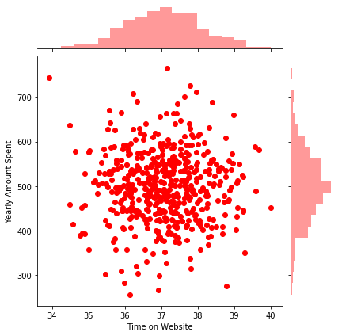

```python
sns.jointplot(df['Time on Website'],df['Yearly Amount Spent'],color='red')
```

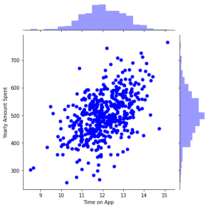

```python
sns.jointplot(df['Time on App'],df['Yearly Amount Spent'],color='blue')
```

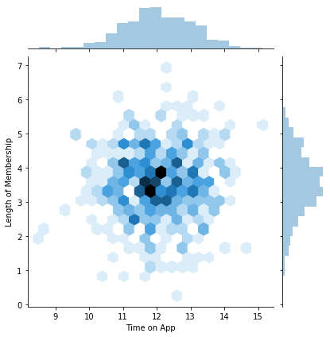

```python
sns.jointplot(df['Time on App'],df['Length of Membership'],kind='hex')
```

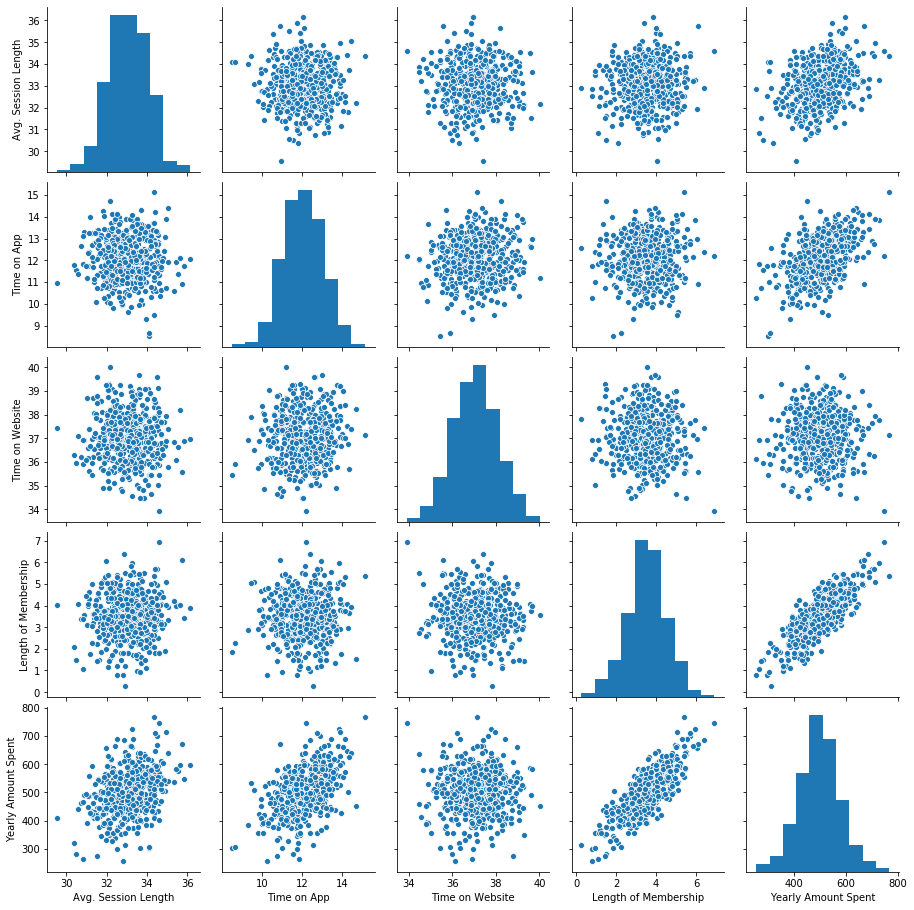

```python
sns.pairplot(df)
```

```python
df.corr()
```

|  | Avg. Session Length | Time on App | Time on Website | Length of Membership | Yearly Amount Spent |
| --- | --- | --- | --- | --- | --- |
| Avg. Session Length | 1.000000 | -0.027826 | -0.034987 | 0.060247 | 0.355088 |
| Time on App | -0.027826 | 1.000000 | 0.082388 | 0.029143 | 0.499328 |
| Time on Website | -0.034987 | 0.082388 | 1.000000 | -0.047582 | -0.002641 |
| Length of Membership | 0.060247 | 0.029143 | -0.047582 | 1.000000 | 0.809084 |
| Yearly Amount Spent | 0.355088 | 0.499328 | -0.002641 | 0.809084 | 1.000000 |

Based on this plot we can look that the Length of Membership column is the most correlated feature with Yearly Amount Spent. It makes sense because the longer you become a member the bigger your possibility to spent more money on it. We can see that on the correlation value table also.

# Data Pre-processing

```python
X=df.select_dtypes(exclude='object').drop('Yearly Amount Spent',axis=1)
Y=df['Yearly Amount Spent']
X
```

|  | Avg. Session Length | Time on App | Time on Website | Length of Membership |
| --- | --- | --- | --- | --- |
| 0 | 34.497268 | 12.655651 | 39.577668 | 4.082621 |
| 1 | 31.926272 | 11.109461 | 37.268959 | 2.664034 |
| 2 | 33.000915 | 11.330278 | 37.110597 | 4.104543 |
| 3 | 34.305557 | 13.717514 | 36.721283 | 3.120179 |
| 4 | 33.330673 | 12.795189 | 37.536653 | 4.446308 |
| ... | ... | ... | ... | ... |
| 495 | 33.237660 | 13.566160 | 36.417985 | 3.746573 |
| 496 | 34.702529 | 11.695736 | 37.190268 | 3.576526 |
| 497 | 32.646777 | 11.499409 | 38.332576 | 4.958264 |
| 498 | 33.322501 | 12.391423 | 36.840086 | 2.336485 |
| 499 | 33.715981 | 12.418808 | 35.771016 | 2.735160 |

500 rows × 4 columns

```python
Y
```

```
0      587.951054
1      392.204933
2      487.547505
3      581.852344
4      599.406092
          ...
495    573.847438
496    529.049004
497    551.620145
498    456.469510
499    497.778642
Name: Yearly Amount Spent, Length: 500, dtype: float64
```

```python
from sklearn.model_selection import train_test_split
X_train,X_test,Y_train,Y_test=train_test_split(X,Y,test_size=0.3,random_state=101)
```

```python
X_train
```

|  | Avg. Session Length | Time on App | Time on Website | Length of Membership |
| --- | --- | --- | --- | --- |
| 202 | 31.525752 | 11.340036 | 37.039514 | 3.811248 |
| 428 | 31.862741 | 14.039867 | 37.022269 | 3.738225 |
| 392 | 33.258238 | 11.514949 | 37.128039 | 4.662845 |
| 86 | 33.877779 | 12.517666 | 37.151921 | 2.669942 |
| 443 | 33.025020 | 12.504220 | 37.645839 | 4.051382 |
| ... | ... | ... | ... | ... |
| 63 | 32.789773 | 11.670066 | 37.408748 | 3.414688 |
| 326 | 33.217188 | 10.999684 | 38.442767 | 4.243813 |
| 337 | 31.827979 | 12.461147 | 37.428997 | 2.974737 |
| 11 | 33.879361 | 11.584783 | 37.087926 | 3.713209 |
| 351 | 32.189845 | 11.386776 | 38.197483 | 4.808320 |

350 rows × 4 columns

```python
X_test
```

|  | Avg. Session Length | Time on App | Time on Website | Length of Membership |
| --- | --- | --- | --- | --- |
| 18 | 32.187812 | 14.715388 | 38.244115 | 1.516576 |
| 361 | 32.077590 | 10.347877 | 39.045156 | 3.434560 |
| 104 | 31.389585 | 10.994224 | 38.074452 | 3.428860 |
| 4 | 33.330673 | 12.795189 | 37.536653 | 4.446308 |
| 156 | 32.294642 | 12.443048 | 37.327848 | 5.084861 |
| ... | ... | ... | ... | ... |
| 147 | 32.255901 | 10.480507 | 37.338670 | 4.514122 |
| 346 | 32.765665 | 12.506548 | 35.823467 | 3.126509 |
| 423 | 33.128693 | 10.398458 | 36.683393 | 3.859818 |
| 17 | 32.338899 | 12.013195 | 38.385137 | 2.420806 |
| 259 | 32.096109 | 10.804891 | 37.372762 | 2.699562 |

150 rows × 4 columns

```python
Y_train
```

```
202    443.965627
428    556.298141
392    549.131573
86     487.379306
443    561.516532
          ...
63     483.159721
326    505.230068
337    440.002748
11     522.337405
351    533.396554
Name: Yearly Amount Spent, Length: 350, dtype: float64
```

```python
Y_test
```

```
18     452.315675
361    401.033135
104    410.069611
4      599.406092
156    586.155870
          ...
147    479.731938
346    488.387526
423    461.112248
17     407.704548
259    375.398455
Name: Yearly Amount Spent, Length: 150, dtype: float64
```

# Linear Regression

```python
from sklearn.linear_model import LinearRegression
regressor = LinearRegression()
regressor.fit(X_train,Y_train)
```

```
LinearRegression(copy_X=True, fit_intercept=True, n_jobs=None, normalize=False)
```

```python
regressor.coef_
```

```
array([25.98154972, 38.59015875,  0.19040528, 61.27909654])
```

# Prediction and Plots

```python
y_pred=regressor.predict(X_test)
```

```python
y_pred
```

```
array([456.44186104, 402.72005312, 409.2531539 , 591.4310343 ,
       590.01437275, 548.82396607, 577.59737969, 715.44428115,
       473.7893446 , 545.9211364 , 337.8580314 , 500.38506697,
       552.93478041, 409.6038964 , 765.52590754, 545.83973731,
       693.25969124, 507.32416226, 573.10533175, 573.2076631 ,
       397.44989709, 555.0985107 , 458.19868141, 482.66899911,
       559.2655959 , 413.00946082, 532.25727408, 377.65464817,
       535.0209653 , 447.80070905, 595.54339577, 667.14347072,
       511.96042791, 573.30433971, 505.02260887, 565.30254655,
       460.38785393, 449.74727868, 422.87193429, 456.55615271,
       598.10493696, 449.64517443, 615.34948995, 511.88078685,
       504.37568058, 515.95249276, 568.64597718, 551.61444684,
       356.5552241 , 464.9759817 , 481.66007708, 534.2220025 ,
       256.28674001, 505.30810714, 520.01844434, 315.0298707 ,
       501.98080155, 387.03842642, 472.97419543, 432.8704675 ,
       539.79082198, 590.03070739, 752.86997652, 558.27858232,
       523.71988382, 431.77690078, 425.38411902, 518.75571466,
       641.9667215 , 481.84855126, 549.69830187, 380.93738919,
       555.18178277, 403.43054276, 472.52458887, 501.82927633,
       473.5561656 , 456.76720365, 554.74980563, 702.96835044,
       534.68884588, 619.18843136, 500.11974127, 559.43899225,
       574.8730604 , 505.09183544, 529.9537559 , 479.20749452,
       424.78407899, 452.20986599, 525.74178343, 556.60674724,
       425.7142882 , 588.8473985 , 490.77053065, 562.56866231,
       495.75782933, 445.17937217, 456.64011682, 537.98437395,
       367.06451757, 421.12767301, 551.59651363, 528.26019754,
       493.47639211, 495.28105313, 519.81827269, 461.15666582,
       528.8711677 , 442.89818166, 543.20201646, 350.07871481,
       401.49148567, 606.87291134, 577.04816561, 524.50431281,
       554.11225704, 507.93347015, 505.35674292, 371.65146821,
       342.37232987, 634.43998975, 523.46931378, 532.7831345 ,
       574.59948331, 435.57455636, 599.92586678, 487.24017405,
       457.66383406, 425.25959495, 331.81731213, 443.70458331,
       563.47279005, 466.14764208, 463.51837671, 381.29445432,
       411.88795623, 473.48087683, 573.31745784, 417.55430913,
       543.50149858, 547.81091537, 547.62977348, 450.99057409,
       561.50896321, 478.30076589, 484.41029555, 457.59099941,
       411.52657592, 375.47900638])
```

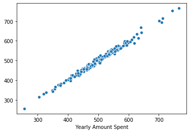

```python
sns.scatterplot(Y_test,y_pred)
```

```python
regressor.score(X_test,Y_test)
```

```
0.9890046246741234
```

```python
cdf=pd.DataFrame(regressor.coef_,X.columns,columns=["coeff"])
```

```python
cdf
```

|  | coeff |
| --- | --- |
| Avg. Session Length | 25.981550 |
| Time on App | 38.590159 |
| Time on Website | 0.190405 |
| Length of Membership | 61.279097 |